# To Bayes or to Bootstrap - that is the question

Ullrika Sahlin and Dmytro Perepolkin, Lund University

18 October 2019

# About this tutorial

This tutorial compares quantifying epistemic uncertainty by Bayesian inference with the Bootstrap method. Bootstrap is a method that frequentists often use to get estimation errors or probability intervals to their estimates, when that doesn’t follow automatically from the analysis. The Bootstrap method generates a sample from a test statistic/parameter or variable of interest. You always get a probability distribution or sample with Bayesian inference. We discuss in what way it may be easier or more difficult to embrace a bootstrap compared to a Bayesian analysis using a general mixed model for illustration. Our conclusion is that Bayesian inference is a coherent principle for inference and more straightforward to implement than the Bootstrap method added to a frequentist analysis.

The tutorial produced for **BayesDays at Liverpool 2019**.

```r
library(readr)
library(ggplot2)
library(gridExtra)
library(dplyr)
library(tidyr) # note that you need to update to current CRAN version
library(modelr)
library(tidybayes)
library(lme4)
library(brms)
library(future)
theme_set(theme_minimal())
```

## Read in data

We will use a data set on birds in agricultural landscape. The data is taken from this publication: *Stjernman, M., Sahlin, U., Olsson, O., and Smith, H. G.. 2019. Estimating effects of arable land use intensity on farmland birds using joint species modeling. Ecological Applications 29( 4):e01875. 10.1002/eap.1875*

### Load data

Let’s load the data and have a look at it.

```r
df <- read_csv2("data/DataEcologicalApplications_jan2019.csv")

glimpse(df)
```

```
## Observations: 66
## Variables: 26
## $ landscape       <chr> "Lsc_1", "Lsc_1", "Lsc_2", "Lsc_2", "Lsc_3", "Ls…
## $ design          <chr> "Flower", "Flower", "Ley", "Ley", "Ley", "Ley", …
## $ visit           <dbl> 1, 2, 1, 2, 1, 2, 1, 2, 1, 2, 1, 2, 1, 2, 1, 2, …
## $ observer        <chr> "MS", "YH", "YH", "PO", "YH", "JD", "JD", "PO", …
## $ npoint          <dbl> 16, 16, 16, 16, 16, 16, 14, 14, 16, 16, 13, 13, …
## $ countWc         <dbl> 1, 0, 0, 1, 0, 0, 0, 1, 1, 1, 0, 0, 0, 0, 0, 0, …
## $ countYh         <dbl> 1, 0, 0, 0, 4, 6, 4, 1, 5, 8, 3, 7, 0, 0, 4, 10,…
## $ countYW         <dbl> 5, 0, 4, 2, 0, 0, 0, 0, 0, 1, 2, 3, 7, 5, 0, 1, …
## $ countLi         <dbl> 8, 2, 2, 3, 0, 3, 1, 0, 2, 4, 1, 4, 4, 2, 3, 7, …
## $ countBS         <dbl> 7, 0, 13, 8, 12, 23, 11, 12, 10, 22, 2, 8, 4, 8,…
## $ countTS         <dbl> 25, 16, 20, 15, 18, 17, 3, 7, 2, 20, 3, 1, 4, 22…
## $ countRo         <dbl> 2, 6, 1, 0, 24, 11, 0, 0, 20, 21, 0, 0, 8, 20, 1…
## $ countSt         <dbl> 0, 0, 8, 8, 8, 5, 12, 26, 10, 38, 5, 2, 0, 1, 11…
## $ countSk         <dbl> 40, 27, 32, 11, 12, 16, 14, 10, 13, 32, 5, 2, 16…
## $ countCu         <dbl> 0, 0, 0, 1, 0, 0, 0, 0, 0, 0, 0, 0, 1, 0, 0, 1, …
## $ countWe         <dbl> 0, 0, 0, 1, 0, 0, 0, 0, 0, 0, 0, 0, 0, 0, 0, 6, …
## $ countRbS        <dbl> 0, 0, 0, 0, 2, 0, 0, 0, 1, 0, 0, 0, 0, 0, 0, 0, …
## $ countLa         <dbl> 8, 4, 0, 5, 0, 0, 0, 0, 7, 1, 1, 0, 1, 0, 1, 5, …
## $ countGW         <dbl> 7, 5, 5, 6, 10, 13, 10, 6, 16, 14, 9, 8, 7, 14, …
## $ countMP         <dbl> 2, 0, 1, 3, 0, 0, 0, 0, 1, 0, 0, 0, 0, 0, 0, 0, …
## $ Farml.area      <dbl> 278.4827, 278.4827, 281.5711, 281.5711, 248.4926…
## $ LHI             <dbl> -1.09159141, -1.09159141, -0.80625838, -0.806258…
## $ Prop.ext.       <dbl> 0.06294152, 0.06294152, 0.24146014, 0.24146014, …
## $ Ext.qual.       <dbl> 0.8885561, 0.8885561, 0.3618538, 0.3618538, 0.26…
## $ Cropdiv.        <dbl> 4.467176, 4.467176, 4.799281, 4.799281, 4.987755…
## $ `Prop.spr-sown` <dbl> 0.2600593, 0.2600593, 0.6258302, 0.6258302, 0.39…
```

## Model description

Data are collected in different sites (**landscapes**) and by different birdwatchers (**observer**). Unexplained variation due to landscape and observer are treated as random effects.

Since the response is a count variable and we have both fixed and random effects we will use a Generalized Linear Mixed Model (GLMM).

Before continuing, we will scale one of the predictors (to improve convergence), give a generic name on the response variable (to easily replace it with other species) and create a categorical variable of one of the predictions (for plotting).

```r
df <- df %>%
  mutate(sFarml_area = as.vector(scale(Farml.area))) %>%
  rename(birdcount = countSk) %>%
  mutate(landscape_type = cut(LHI, breaks=c(-10,0.5,10),
                              labels=c('simple','complex')))
```

### Plot the data

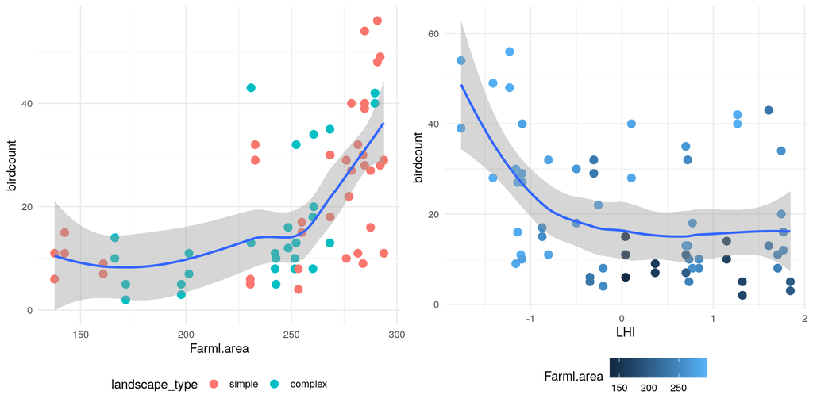

```r
p1 <- ggplot(df, aes(x = Farml.area, y = birdcount)) +
  geom_point(size = 3,aes(colour = landscape_type))+
  geom_smooth(method = loess)+
  theme(legend.position="bottom")

p2 <- ggplot(df, aes(x = LHI, y = birdcount)) +
  geom_point(size = 3,aes(colour = Farml.area))+
  geom_smooth(method = loess)+
  theme(legend.position="bottom")

gridExtra::grid.arrange(p1, p2, ncol = 2)
```

# Classical inference

Let us first see how this model can be parametrised using classical (likelihood-based) inference. We estimate parameters of the GLMM using `glmer()` in the `lme4` R-package.

```r
mod <- glmer(birdcount ~ sFarml_area * LHI + (1|landscape) + (1|observer) + offset(log(npoint)),
             data = df, family = poisson)
summary(mod)
```

```
## Generalized linear mixed model fit by maximum likelihood (Laplace
##   Approximation) [glmerMod]
##  Family: poisson  ( log )
## Formula:
## birdcount ~ sFarml_area * LHI + (1 | landscape) + (1 | observer) +
##     offset(log(npoint))
##    Data: df
##
##      AIC      BIC   logLik deviance df.resid
##    460.7    473.8   -224.3    448.7       60
##
## Scaled residuals:
##      Min       1Q   Median       3Q      Max
## -1.77418 -0.49922 -0.05439  0.47235  1.76432
##
## Random effects:
##  Groups    Name        Variance Std.Dev.
##  landscape (Intercept) 0.1348   0.3671
##  observer  (Intercept) 0.1474   0.3840
## Number of obs: 66, groups:  landscape, 33; observer, 5
##
## Fixed effects:
##                 Estimate Std. Error z value Pr(>|z|)
## (Intercept)      0.09519    0.19419   0.490 0.624006
## sFarml_area      0.32926    0.08850   3.721 0.000199 ***
## LHI             -0.10671    0.08473  -1.259 0.207888
## sFarml_area:LHI  0.07950    0.10781   0.737 0.460895
## ---
## Signif. codes:  0 '***' 0.001 '**' 0.01 '*' 0.05 '.' 0.1 ' ' 1
##
## Correlation of Fixed Effects:
##             (Intr) sFrml_ LHI
## sFarml_area -0.135
## LHI         -0.165  0.528
## sFrml_r:LHI  0.274 -0.329 -0.475
```

## Extracting information from the model

```r
getME(mod,'theta')
```

```
## landscape.(Intercept)  observer.(Intercept)
##             0.3670881             0.3839673
```

## Check the model

### Study residuals and goodnes-of-fit

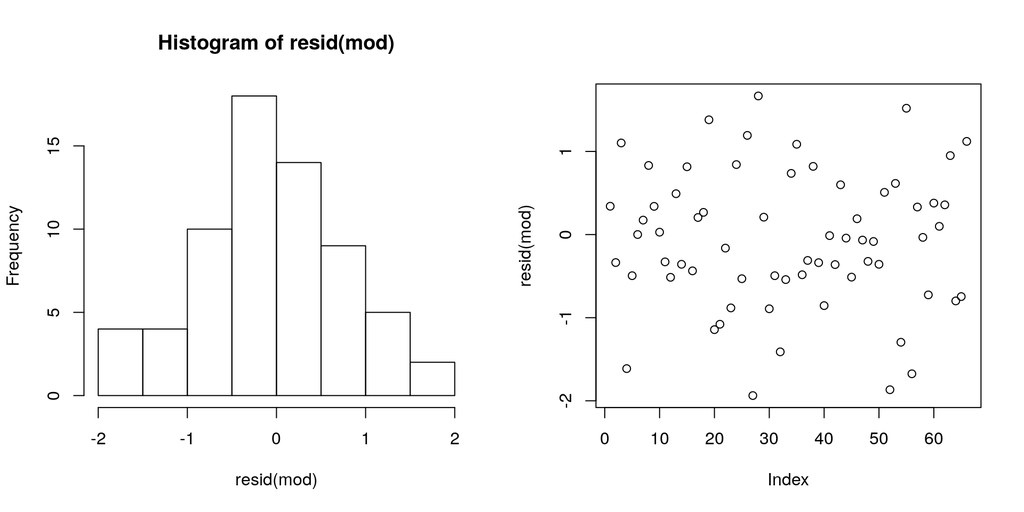

```r
par(mfrow=c(1,2))
hist(resid(mod)); plot(resid(mod))
```

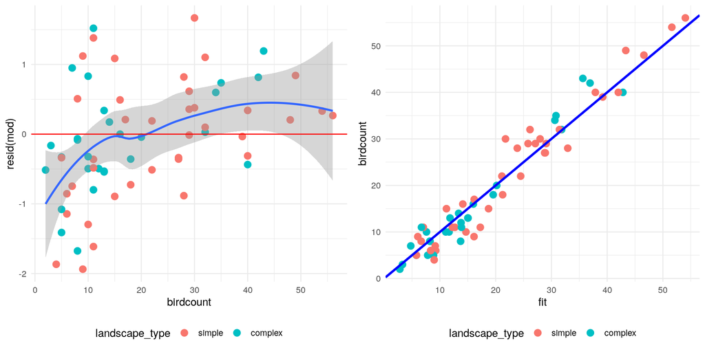

```r
p1 <- ggplot(df, aes(x=birdcount, y=resid(mod))) +
  geom_point(size=3, aes(colour = landscape_type))+
  geom_smooth(method=loess) +
  geom_hline(aes(yintercept = 0),col='red')+
  theme(legend.position = "bottom")

df <- df %>%
  add_predictions(mod, var="fit", type='response')

p2 <- ggplot(df,aes(x=fit,y=birdcount)) +
         geom_point(size = 3, aes(colour = landscape_type)) +
         geom_abline(col='blue',lwd = 1.12)+
  theme(legend.position = "bottom")
gridExtra::grid.arrange(p1, p2, ncol=2)
```

## Making predictions

### Predict training data

Make predictions of bird counts for the data we have. Predictions can be made with estimated random effects, but are provided without errors or uncertainty ranges.

What data or information do we have in the different columns?

```r
df %>%
  select(birdcount) %>%
  mutate(all_random_effects=predict(mod, type='response', re.form=NULL),
         landscape_random_effect=predict(mod,type = 'response',re.form = ~(1|landscape)),
         no_random_effects=predict(mod,type = 'response',re.form = NA))
```

```
## # A tibble: 66 x 4
##    birdcount all_random_effects landscape_random_effect no_random_effects
##        <dbl>              <dbl>                   <dbl>             <dbl>
##  1        40              37.9                    24.7              23.6
##  2        27              28.8                    24.7              23.6
##  3        32              26.2                    22.4              23.7
##  4        11              17.2                    22.4              23.7
##  5        12              13.8                    11.8              15.1
##  6        16              16.0                    11.8              15.1
##  7        14              13.4                     9.87              6.55
##  8        10               7.60                    9.87              6.55
##  9        13              11.8                    20.7              17.3
## 10        32              31.8                    20.7              17.3
## # … with 56 more rows
```

### Predict new data

Make predictions of bird counts for new data. First we create a new data set. Then we use the predict-function. The random effect is zero by default and still no uncertainty provided with the predictions.

```r
newdata <- data_grid(df, sFarml_area = seq_range(sFarml_area, 20),
                         LHI = c(-2, 1), npoint = 16) %>%
    mutate(landscape_type=cut(LHI,breaks=c(-10,0.5,10),
                            labels=c('simple','complex')))

birdcount <- predict(mod, newdata=newdata, re.form = NA, type = 'response')
head(birdcount)
```

```
##         1         2         3         4         5         6
## 14.545241  5.997340 15.000844  6.458279 15.470719  6.954644
```

## Use bootstrap to predict with uncertainty

We can perform model-based (semi-)parametric bootstrap of our mixed model (Poisson regression) using using `bootMer()` in `lme4` package.

### Predict with estimation error

```r
bm <- bootMer(mod, FUN = function(.){predict(., newdata=newdata, re.form = NA, type = 'response')}, nsim = 100 )
```

The bootstrap returns a sample for each prediction.

```r
head(bm$t[,1:6])
```

```
##              1        2         3        4         5        6
## [1,] 33.346100 5.478108 32.625284 5.850164 31.920049 6.247490
## [2,] 28.809035 5.156318 29.337613 5.699993 29.875890 6.300992
## [3,] 12.671344 5.572445 13.066895 6.035030 13.474793 6.536016
## [4,] 21.328661 7.073383 21.565991 7.535942 21.805962 8.028751
## [5,]  5.953642 4.759509  6.439551 5.227209  6.965118 5.740868
## [6,] 42.821032 6.820542 41.202642 7.250380 39.645417 7.707307
```

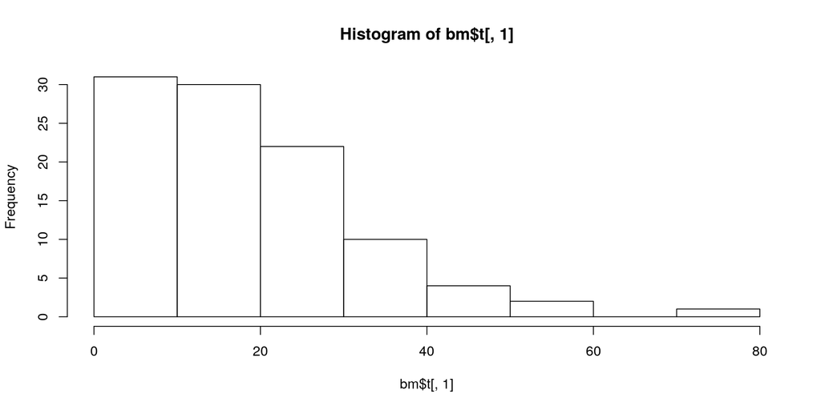

```r
hist(bm$t[,1])
```

Plot bird abundance over farmland area.

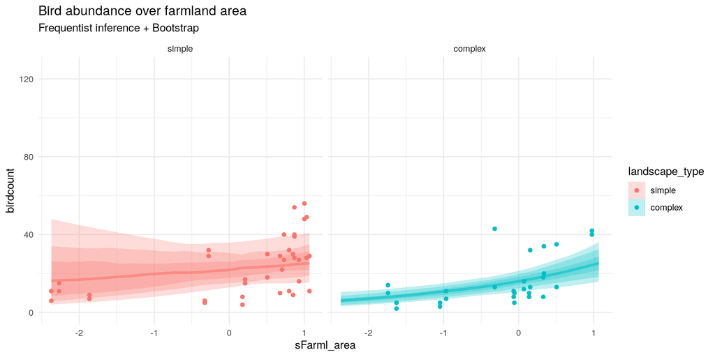

```r
df_pred1 <- newdata %>%
  add_draws(draws = bm$t, value = ".prediction")
df %>%
  ggplot(aes(x = sFarml_area, y = birdcount, color = landscape_type, fill = landscape_type)) +
  geom_point(aes(x = sFarml_area, y = birdcount)) +
  stat_lineribbon(data=df_pred1, aes(y = .prediction), .width = c(.95, .80, .50), alpha = 1/4) +
  ylim(c(0,125)) +
  facet_wrap(~landscape_type) +
  labs(title = 'Bird abundance over farmland area', subtitle = "Frequentist inference + Bootstrap")
```

### Predict with estimation error and landscape variability

To include uncertainty from landscape random effect we draw random normally distributed values to the predictions.

```r
bm.withlandscaperandom <- bootMer(mod, FUN = function(.){
  log_count <- predict(., newdata=newdata, re.form = NA, type = 'link') + rnorm(nrow(newdata),0,sqrt(getME(mod,'theta')[1]))
  exp(log_count)}, nsim = 100 )
```

### Plot

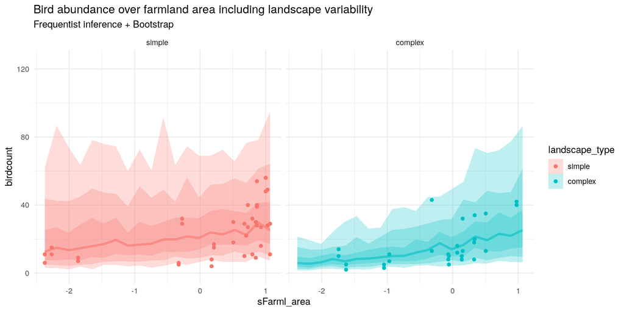

```r
df_pred2 <- newdata %>%
  add_draws(draws = bm.withlandscaperandom$t, value = ".prediction")
df %>%
  ggplot(aes(x = sFarml_area, y = birdcount, color = landscape_type, fill = landscape_type)) +
  geom_point(aes(x = sFarml_area, y = birdcount)) +
  stat_lineribbon(data=df_pred2, aes(y = .prediction), .width = c(.95, .80, .50), alpha = 1/4) +
  ylim(c(0,125)) +
  facet_wrap(~landscape_type) +
  labs(title = 'Bird abundance over farmland area including landscape variability', subtitle = "Frequentist inference + Bootstrap")
```

# Bayesian inference

A Bayesian version of the GLMM is implemented in the `brms` R-package, which uses almost the same syntax as `lme4`. A stan model is created as a C++ code and the brm-function calls STAN for **MCMC sampling**.

```r
future::plan("multiprocess")
bmod <- brm(birdcount ~ sFarml_area * LHI + (1|landscape) + (1|observer) + offset(log(npoint)),
            data = df, family = poisson(), future = TRUE, silent = TRUE)
```

## Study the model

```r
summary(bmod)
```

```
##  Family: poisson
##   Links: mu = log
## Formula: birdcount ~ sFarml_area * LHI + (1 | landscape) + (1 | observer) + offset(log(npoint))
##    Data: df (Number of observations: 66)
## Samples: 4 chains, each with iter = 2000; warmup = 1000; thin = 1;
##          total post-warmup samples = 4000
##
## Group-Level Effects:
## ~landscape (Number of levels: 33)
##               Estimate Est.Error l-95% CI u-95% CI Rhat Bulk_ESS Tail_ESS
## sd(Intercept)     0.41      0.07     0.29     0.57 1.00     1304     2223
##
## ~observer (Number of levels: 5)
##               Estimate Est.Error l-95% CI u-95% CI Rhat Bulk_ESS Tail_ESS
## sd(Intercept)     0.64      0.32     0.27     1.49 1.01      849     1691
##
## Population-Level Effects:
##                 Estimate Est.Error l-95% CI u-95% CI Rhat Bulk_ESS
## Intercept           0.09      0.33    -0.59     0.76 1.00      968
## sFarml_area         0.34      0.09     0.15     0.52 1.00     1617
## LHI                -0.10      0.09    -0.29     0.08 1.00     1497
## sFarml_area:LHI     0.08      0.12    -0.15     0.31 1.00     1766
##                 Tail_ESS
## Intercept           1173
## sFarml_area         2136
## LHI                 1818
## sFarml_area:LHI     1763
##
## Samples were drawn using sampling(NUTS). For each parameter, Eff.Sample
## is a crude measure of effective sample size, and Rhat is the potential
## scale reduction factor on split chains (at convergence, Rhat = 1).
```

## Make predictions with uncertainty

```r
df_pred_b1 <- df %>%
  data_grid(sFarml_area = seq_range(sFarml_area, n = 20),
            LHI = c(-2,1), landscape = NA, observer = NA, npoint = 16) %>%
  mutate(landscape_type=cut(LHI,breaks=c(-10,0.5,10), labels=c('simple','complex'))) %>%
    add_predicted_draws(bmod, value =".prediction", re_formula = NA)
```

### Plot

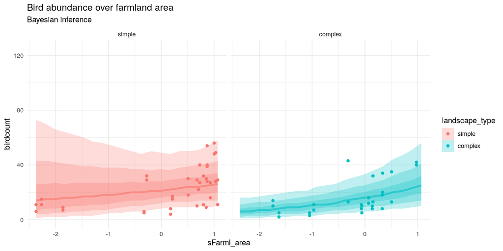

```r
df %>%
  ggplot(aes(x = sFarml_area, y = birdcount, color = landscape_type, fill = landscape_type)) +
  geom_point(aes(x = sFarml_area, y = birdcount)) +
  stat_lineribbon(data=df_pred_b1, aes(y = .prediction), .width = c(.95, .80, .50), alpha = 1/4) +
  ylim(c(0,125)) +
  facet_wrap(~landscape_type) +
  labs(title = 'Bird abundance over farmland area', subtitle = "Bayesian inference")
```

## Predict with uncertainty including landscape variability

```r
df_pred_b2 <- df %>%
  data_grid(sFarml_area = seq_range(sFarml_area, n = 20),
            LHI = c(-2,1), landscape = NA, observer = NA, npoint = 16) %>%
  mutate(landscape_type=cut(LHI,breaks=c(-10,0.5,10), labels=c('simple','complex'))) %>%
  add_predicted_draws(bmod, value =".prediction", re_formula = ~(1|landscape),allow_new_levels = TRUE)
```

### Plot

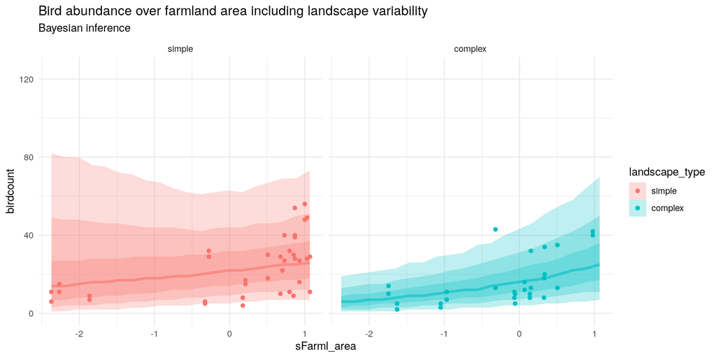

```r
df %>%
  ggplot(aes(x = sFarml_area, y = birdcount, color = landscape_type, fill = landscape_type)) +
  geom_point(aes(x = sFarml_area, y = birdcount)) +
  stat_lineribbon(data=df_pred_b2, aes(y = .prediction), .width = c(.95, .80, .50), alpha = 1/4) +
  ylim(c(0,125)) +
  facet_wrap(~landscape_type) +
  labs(title = 'Bird abundance over farmland area including landscape variability', subtitle = "Bayesian inference")
```

# Comparison

Is there a difference in predictions using the two approaches?